# DS202 2022 MT - Summative Problem Set 03

DS202 2022MT Teaching Group

5 December 2022

# 🆔 Identification

THIS IS AN ANONYMOUS SUBMISSION. DO NOT INCLUDE YOUR NAME NOR OTHER PERSONAL INFORMATION ANYWHERE IN THIS FILE OTHER THAN YOUR CANDIDATE NUMBER.

```r
# Complete the line below by filling it out with your CANDIDATE NUMBER

candidate_number <- 00000
```

💡 Avoid the last-minute panic. Clear your R environment and knit your RMarkdown every once in a while to ensure your solution is compiling correctly.

# 🎯 Exam-style questions

- The first three questions do not require writing any R code.
- These questions are worth 30 points and are also a taster of the style of the non-code questions you can expect from the January exam.

## Q1. Linear Regression (5 points)

What metric does Ordinary Least Square (OLS) optimise? And how does OLS estimate regression coefficients?

> OLS optimizes the sum of squared residuals (SSR). It estimates the regression coefficients by minimizing the sum of squared residuals. This is done by finding the values of the coefficients that make the sum of the squared differences between the observed values and the predicted values as small as possible.

**✒️️ Marking Rubric: how you will be assessed**

- What a great answer! (5/5): Not only is the explanation correct, it is also very clear and concise (not vague, imprecise or unnecessarily verbose)
- Correct (4/5): The answer was correct
- Partially Correct (~3): Answer was not entirely correct or was confusing to read
- Incorrect (0/5): Response was incorrect or missing

## Q2. Confusion Matrices (10 points)

The two figures below shows the goodness-of-fit of two separate classifiers trained to predict the brand of Orange Juice sales per brand (ISLR2::OJ). Considering we do not have a preference for a particular brand, we want both to be identified correctly, which Classifier performed best?

**Classifier 1**

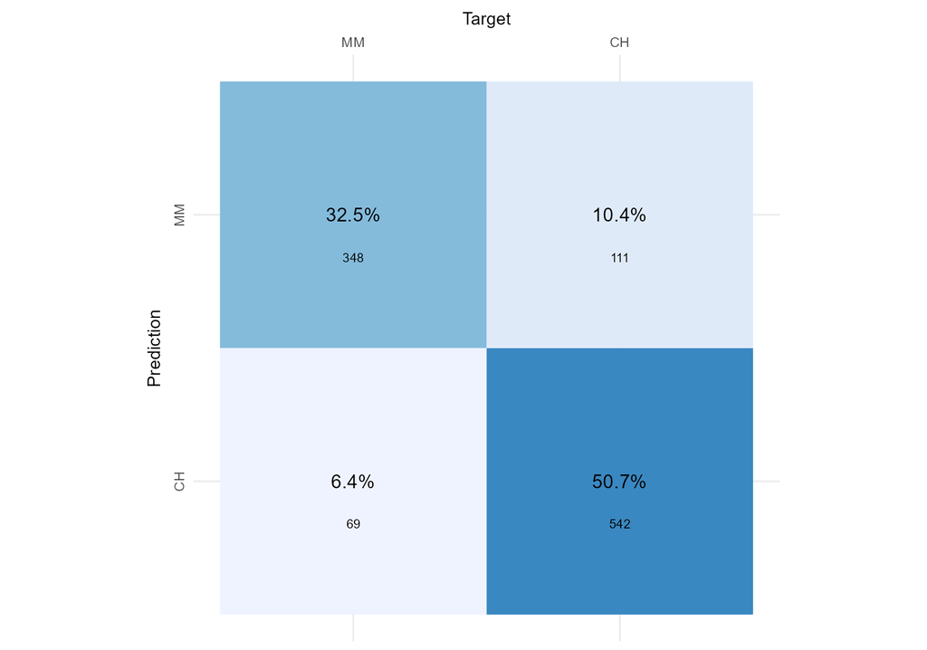

**Classifier 2**

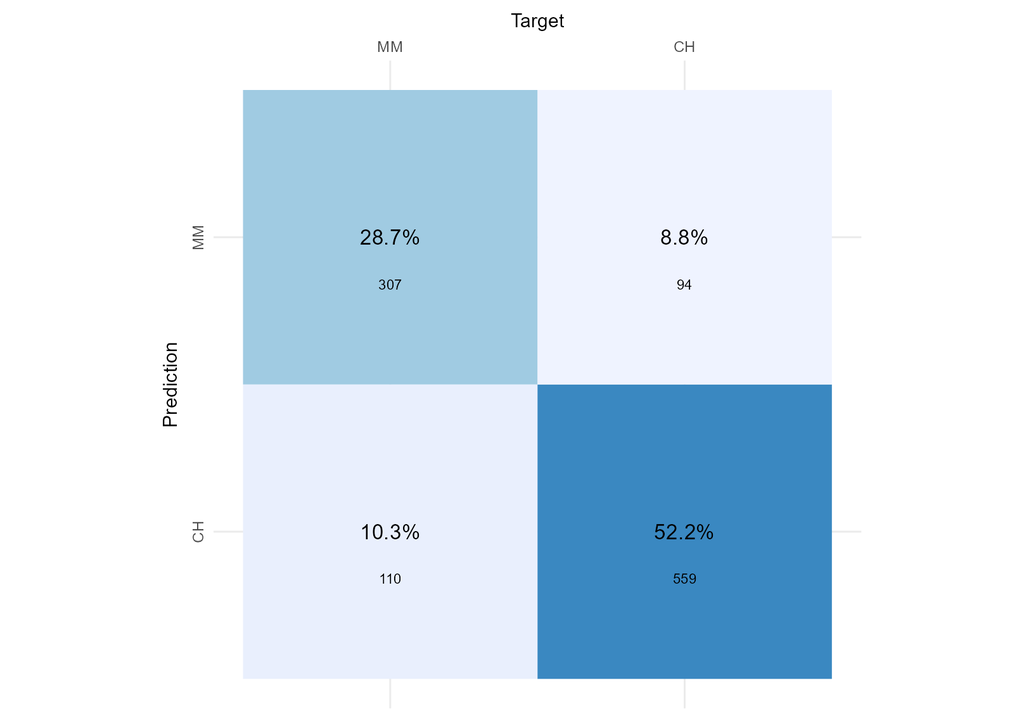

**✒️️ Marking Rubric: how you will be assessed**

- What a great answer! (10/10): Not only is the explanation correct, it is also very clear and concise (not vague, imprecise or unnecessarily verbose)
- Correct (~7/10): The answer was correct
- Partially Correct (~5/10): Answer was OK but it was a bit confusing to read
- Partially Correct (~3/10): Answer was not entirely correct or was confusing to read
- Incorrect (0/10): Response was incorrect or missing

## Q3. Decision Trees (15 points)

For this question, we used the `quanteda.textmodels::data_corpus_moviereviews` corpus. This dataset consists of 2000 movie reviews and we have a target variable, called `sentiment`. The dataset is quite balanced, we have 1000 `sentiment="yes"` (indicating a positive sentiment towards the movie), the other 1000, `sentiment="no"`, indicating a negative review.

We trained two separate decision trees, one with `tree_depth=1` and another with `tree_depth=4`, on this dataset. As you probably know, the figures below depicts the fitted trees, and it contains useful information about how well the models fit the training data. Here is what we want from you: based on the information contained in these figures, calculate the F1-score of each model for the target variable `sentiment="yes"`, explain how you calculated the scores and indicate which of the two models performed better.

**Decision Tree Model 1**

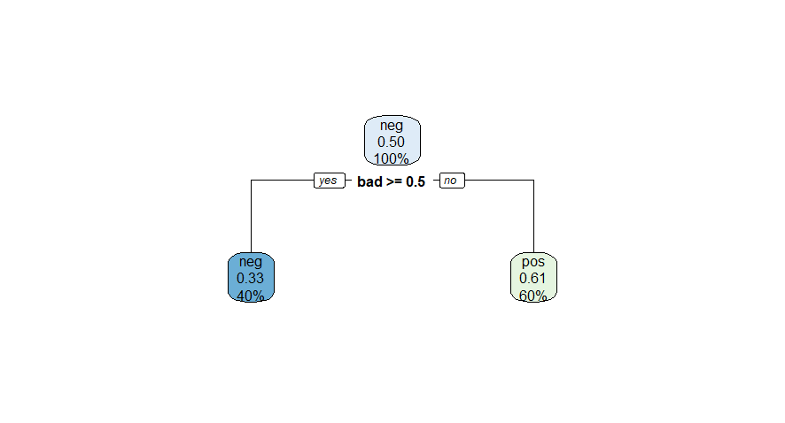

**Decision Tree Model 2**

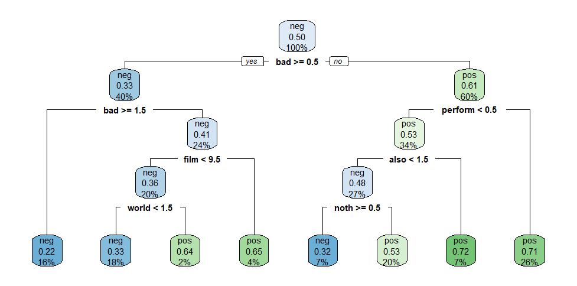

**✒️️ Marking Rubric: how you will be assessed**

- What a great answer! (15/15): Not only your answer was correct, it was very clear and engaging! You correctly explained how you calculated the F1-score and it was clear if and how one model was better than the other.
- Correct (12/15) You correctly explained how you calculated the F1-score and it was clear if and how one model was better than the other.
- Partially Correct (~8/15): You reached the correct F1 scores but your solution was a bit vague or imprecise.
- Partially Correct (~5/15): Even though you reached the correct F1 scores, you did not explain how you calculated the scores satisfactorily.
- Incorrect (0): Response was incorrect or missing

# ⚙️ Setup to coding questions

Your goal will be to conduct quantitative text analysis using unsupervised learning techniques on a selected dataset.

**This time, you will be responsible for organising your own code!** You will see all the instructions below together with detailed marking criteria, but you will be responsible for adding the chunks of code and chunks of text related to your submission **at the bottom of this document**.

## The data

We will be using a dataset called `zeroshot/twitter-financial-news-topic`, a dataset of finance-related tweets. The dataset holds around 17k documents annotated with 20 labels that were [determined manually by the authors](https://neuralmagic.com/blog/classifying-finance-tweets-in-real-time-with-sparse-transformers/) of the dataset.

## Your choice

Although this is not “big data”, some text mining algorithms might use quite a lot of RAM storage or can take quite some time to run. Thinking of that, we will you give you a choice of how big of a sample you want to work on for this problem set.

You can choose either:

Option 1) use the full dataset as is (`df`) or,

Option 2) select a subset of the data considering the following limitations:

- Select a few `manually_annotated_label` categories and keep only tweets in your selected categories.
- Your filtered dataset must have at least 4000 tweets.

# 🎯 Questions

Now here comes the actual coding questions. Read the instructions below (Q4-Q7) and then add your chunks of code/text at the bottom of this document.

*(Note: Do not worry, this style of question will not feature in the final exam, as you will not have much time to write code.)*

## Q4. Pre-processing (10 points)

*💭 It is often said that 80% of the effort and time put into a data science project is on cleaning and pre-processing data. Because this is a practical hands-on Machine Learning course, we cannot ignore that!*

Write code that meets the requirements below:

- Import all libraries at the top of submission
- Read the dataset
- Filter the `manually_annotated_label` categories (if Option 2)
- Build a corpus of text
- Pre-process the tokens: remove stop words, remove punctuations, remove numbers. If you judge it necessary, remove more tokens.
- Build a document-frequency matrix.

Tip: check the documentation of quanteda’s `?tokens`.

Pro-Tip: Take a look at `?dfm_trim` to reduce the dimensionality of the document frequency matrix (it can *potentially* improve the clarity of analysis).

**✒️️ Marking Rubric: how you will be assessed**

- Fantastic (10/10): Not only the solution ticks all the boxes, the code is well organised, there are no weird prints of warnings or unnecessary messages when importing libraries, and the candidate went an extra mile to check whether any extra filter should be applied when pre-processing the tokens.
- Correct (~7/10): Ticks all the boxes.
- Partial (~4/10): Solution was only partially correct, you forgot to consider a few requirements.
- Incorrect (0/10): The code does not work as required.

## Q5. Topic Modelling (30 points)

*💭 I wonder if topics identified by topic modelling match the labels identified manually by the author of the dataset.*

Write code that does the following:

- Run topic modelling with k topics, where k should match the same number of `manually_annotated_label` categories in your dataset. In other words, if you are using the full dataset (Option 1), k=20.
- Explain what each of the topics you found represent
- Give a meaningful name to each one of the topics you found
- Explain to what extent the topics you found match the labels that came with the original dataset (use tables, plots, etc.)

**✒️️ Marking Rubric: how you will be assessed**

- Fantastic (30/30): We can see that you went an extra mile to format your submission. This is a complex task, involving many steps but you made it look easy, clear and impressive. It should be published somewhere! Not only the solution ticks all the boxes, the code is well organised, the markdown is well formatted and the explanations are good yet concise.
- Correct (~23/30): Solution ticks all the boxes.
- Correct (~20/30): Solution was technically correctly but you could have put more care into communicating your results and explanations.
- Partial (~15/30): Either the solution was partially correct or your code and explanations were a bit difficult to read (vague, overly verbose, complex, etc.)
- Partial (~10/30): Either the solution was partially correct or your code and explanations were very difficult to read (vague, overly verbose, complex, etc.)
- Incorrect (0/10): The code does not work as required.

## Q6. Plots of topics (15 points)

Write code that does the following:

- Select one topic to highlight
- Create a word cloud highlighting the top words from the selected topic against the rest
- Create a plot of keyness for the selected topic against the rest

Tip: Check `?quanteda.textplots::textstat_keyness` and `?quanteda.textplots::textplot_keyness`

**✒️️ Marking Rubric: how you will be assessed**

- Fantastic (15/15): Not only the solution ticks all the boxes, the code is well organised, and your plots and explanations told us an interesting story about the topic you selected.
- Correct (~10/15): Ticks all the boxes.
- Partial (~7/15): Either the solution was partially correct or your code and explanations were a bit difficult to read (vague, overly verbose, complex, etc.)
- Partial (~3/15): Either the solution was partially correct or your code and explanations were very difficult to read (vague, overly verbose, complex, etc.)
- Incorrect (0/15): The code does not work as required.

## Q7. 2D visualisation of the dataset (15 points)

- Produce a 2D scatter plot of the dataset (however you want)
- Colour the dots according to the topics you found in Q5
- Explain if/how this visualisation improved your understanding of the data.

**✒️️ Marking Rubric: how you will be assessed**

- Impressive! (15/15): It is not easy to create such an interesting 2D representation of text data but somehow you made it. It looks like a piece of art.
- Correct (~10/15): Ticks all the boxes.
- Partial (~7/15): Either the solution was partially correct or your code and explanations were a bit difficult to read (vague, overly verbose, complex, etc.)
- Partial (~3/15): Either the solution was partially correct or your code and explanations were very difficult to read (vague, overly verbose, complex, etc.)
- Incorrect (0/15): The code does not work as required.

Your submission starts here. Add everything after this point.

Organise your code as you find fit, aim for clarity in communication.

```r
options(warn = -1)
```

```r
library(tidyverse)
library(tidytext)
library(quanteda)
library(topicmodels)
library(Matrix)
library(reshape)
```

```r
library(quanteda.textplots)
library(quanteda.textstats)
library(wordcloud)
df <-
  read_csv("./zeroshot-twitter-financial-news-topic-recoded.csv")
# Filters the data frame to include only rows with the specified labels in the manually_annotated_label column
new_df <- df %>%
  filter(
    manually_annotated_label %in% c(
      "Dividend",
      "Earnings",
      "Energy | Oil",
      "Legal | Regulation",
      "Markets"
    )
  )

# The text of these rows is extracted and cleaned by removing URLs, excess whitespace, digits, and punctuation.
text <- new_df$text
text <- gsub("(s?)(f|ht)tp(s?)://\\S+\\b", "", text)

text <- gsub("\\s+", " ", text)
text <- gsub('[[:digit:]]+', '', text)
text <- gsub("[[:punct:]]", "", text)
text_df <- tibble(line = 1:length(text), text = text)

# The cleaned text is then tokenized into individual words and joined with the stop_words dataset to remove common English stop words.
tidy_text_df <- text_df %>%
  unnest_tokens(word, text)

data("stop_words")
tidy_text_df <- tidy_text_df %>%
  anti_join(stop_words)
# A document-term matrix is created from the remaining words.
doc_freq_matrix<- tidy_text_df$word %>%
  dfm()
```

```r
#create 5 topics
# create a seed to make the model's output predictable.

doc_freq_matrix_lda <-
  LDA(doc_freq_matrix, k = 5, control = list(seed = 1))
# word_topic probabilities
# use "beta" to extract the per-topic-per-word-probabilities
doc_freq_matrix_topics <- tidy(doc_freq_matrix_lda, matrix = "beta")
# 10 most common term in each topic

doc_freq_matrix_terms <- doc_freq_matrix_topics %>%
  group_by(topic) %>%
  slice_max(beta, n = 10) %>%
  ungroup() %>%
  arrange(topic,-beta)
doc_freq_matrix_terms
```

```
## # A tibble: 50 × 3
##    topic term           beta
##    <int> <chr>         <dbl>
##  1     1 earnings    0.0461
##  2     1 stocks      0.0234
##  3     1 dividend    0.0175
##  4     1 financial   0.0154
##  5     1 conference  0.0133
##  6     1 quarter     0.0119
##  7     1 prices      0.0100
##  8     1 trading     0.00839
##  9     1 stockmarket 0.00821
## 10     1 futures     0.00758
## # … with 40 more rows
```

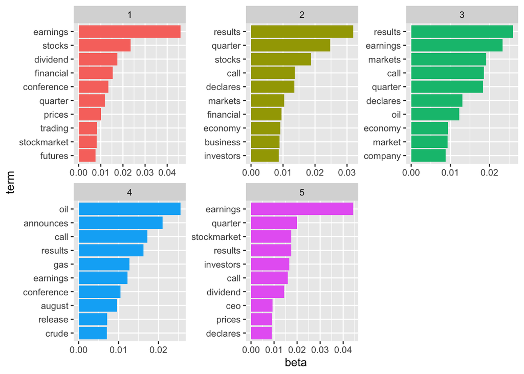

```r
doc_freq_matrix_terms %>%
  mutate(term = reorder_within(term, beta, topic)) %>%
  ggplot(aes(beta, term, fill = factor(topic))) +
  geom_col(show.legend = FALSE) +
  facet_wrap( ~ topic, scales = "free") +
  scale_y_reordered()
```

```r
# document topic probabilities
doc_freq_matrix_documents <-
  tidy(doc_freq_matrix_lda, matrix = "gamma")
doc_freq_matrix_documents
```

```
## # A tibble: 143,655 × 3
##    document topic gamma
##    <chr>    <int> <dbl>
##  1 text1        1 0.201
##  2 text2        1 0.203
##  3 text3        1 0.200
##  4 text4        1 0.202
##  5 text5        1 0.203
##  6 text6        1 0.204
##  7 text7        1 0.202
##  8 text8        1 0.201
##  9 text9        1 0.201
## 10 text10       1 0.203
## # … with 143,645 more rows
```

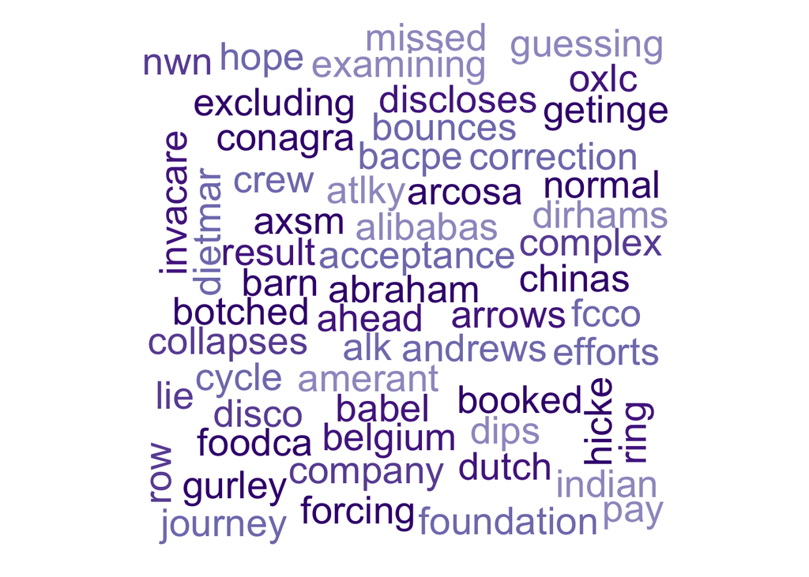

```r
# selecting one of the topics
# selecting topic 1
doc_freq_matrix_topic_1 <- doc_freq_matrix_topics %>%
  filter(topic == 1)

# wordcloud
doc_freq_matrix_topic_1 %>% count(term, sort = T) %>% with(
  wordcloud(
    term,
    n,
    max.words = 100,
    scale = c(2, 0.25),
    min.freq = 10,
    random.order = F,
    random.color = T,
    colors = brewer.pal(9, "Purples")[5:9]
  )
)
```

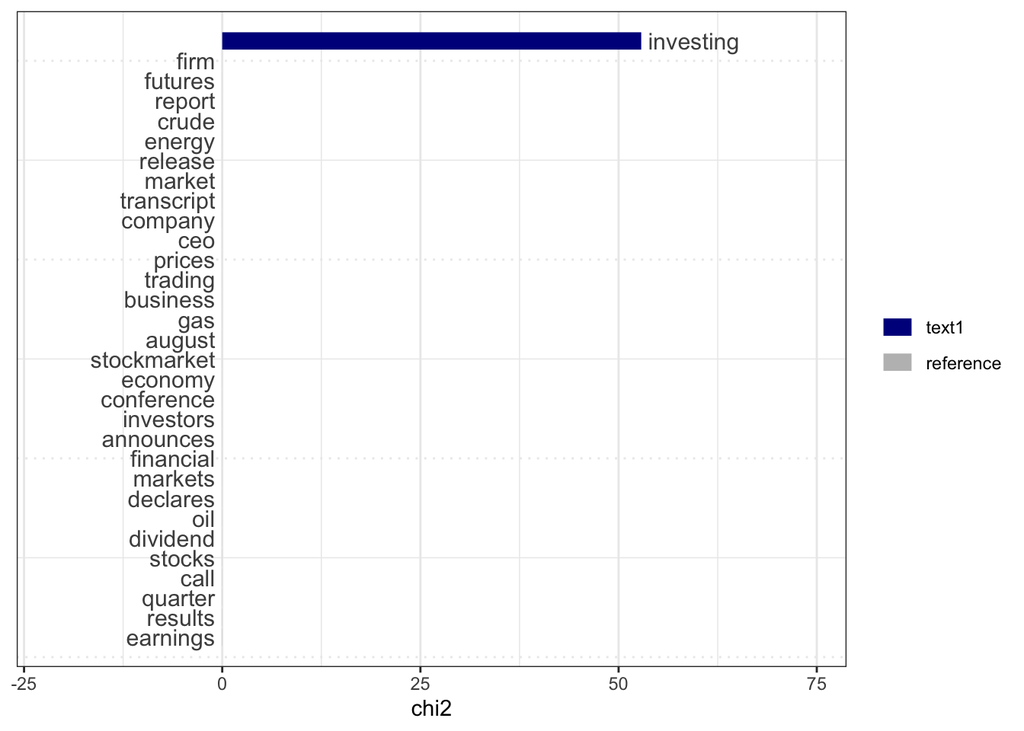

```r
# keyness for selected topics
tstat_topic1 <- textstat_keyness(doc_freq_matrix, target = "text1")

textplot_keyness(tstat_topic1, margin = 0.2, n = 30)
```

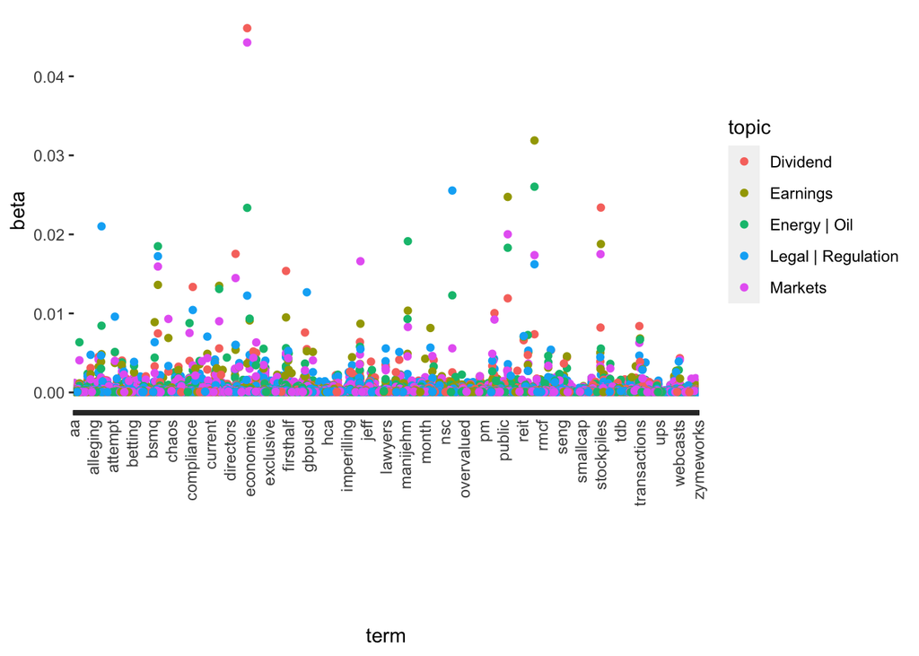

```r
# scatterplot of dataset colored words in the topic

doc_freq_matrix_topics %>%
  filter(beta >= median(beta)) %>%
  mutate(
    topic = factor(topic),
    topic = fct_recode(
      topic,
      "Dividend" = "1",
      "Earnings" = "2",
      "Energy | Oil" = "3",
      "Legal | Regulation" = "4",
      "Markets" = "5"
    )
  ) %>%
  ggplot(aes(x = term, y = beta, color = topic)) +
  geom_point()+
  theme(axis.text.x = element_text(
    angle = 90, vjust = 0.5, hjust = 1
  )) +
  scale_x_discrete(guide = guide_axis(check.overlap = TRUE))
```